# Homework # 2

Orozco Carstensen Ana Paloma

2/17/2022

## **Problem # 1**

Consider the following quantities, discuss and justify what type of probability distribution the following variables can have.

**a.** The size of adult male footwear in Mexico.

```
Answer: Normal or unimodal distribution. Because there are very few with very small or very large sizes, almost all of them will be distributed around the average.
```

**b.** The distribution of inhabitants in human settlements in Mexico.

```
Answer: Normal or unimodal distribution. Because hardly anyone lives in isolation; almost all of them are distributed around the average, in groups of neither many nor few houses.
```

**c.** The average speed of cars in Bernardo Quintana at 09:00am on a weekday.

```
Answer: Normal or unimodal distribution. Because it's going to be almost impossible to go too fast or too slow; almost all of them are going to be distributed around the average (which is not going to be very fast, haha).
```

**d.** The average speed of cars in Bernardo Quintana at 03:00am.

```
Answer: Definitely long tail. Most are going to go very fast and very few are going to go slow, they would not be distributed around the average.
```

## **Problem # 2**

Let’s suppose that we have 2 nodes (A and B) in a network. Node A and B have the same degree, but node A has a clustering coefficient of 1 and node B, low. Draw this situation and explain what would be a better target if you want to eliminate them and affect the network.

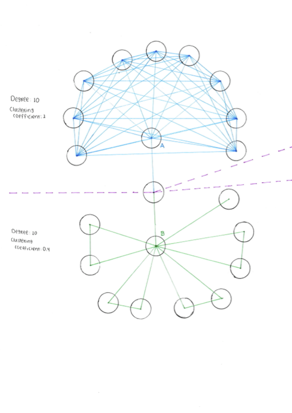

[output not shown]

## **Problem # 3**

Write a program in R that, using functions, calculates from an adjacency matrix:

First, load a matrix to test the functions:

```r
Friends_Network <- read.csv ("Data/Friends_NW.csv") # Load data
row.names (Friends_Network) <- Friends_Network [ , 1] # Take the first column and make it the row names
Friends_Network <- Friends_Network [ , -1] # Take first column
as.matrix (Friends_Network) # Make it matrix
```

```
##                ERICK CAROLINA JULIAN KAREN MITZI MAYELA ENRIQUE NATALY MARIA
## ERICK              0        1      1     0     0      0       1      0     0
## CAROLINA           1        0      0     0     1      0       1      0     1
## JULIAN             1        1      0     1     1      1       1      0     1
## KAREN              0        1      1     0     1      0       0      1     1
## MITZI              0        1      0     1     0      0       0      1     1
## MAYELA             0        0      0     0     0      0       0      0     0
## ENRIQUE            1        0      1     1     1      1       0      0     1
## NATALY             0        1      1     1     1      1       0      0     1
## MARIA              0        1      1     1     1      0       0      1     0
## MARIA_FERNANDA     1        1      1     1     1      1       1      0     1
## ERNESTO            0        1      0     1     1      1       0      1     1
## PALOMA             1        0      1     0     0      1       1      0     0
## XIMENA             0        0      0     0     0      1       0      0     0
## FERNANDA           0        0      0     0     0      1       0      0     0
## ISABEL             0        0      0     0     0      0       0      0     0
## SARA               0        0      0     0     0      0       0      0     0
## CECILIA            0        1      0     0     1      1       0      0     1
## REBECA             1        1      1     1     1      1       1      1     0
## ANDREA             0        1      0     1     1      1       1      1     1
## ADRIAN             1        1      1     0     0      1       1      0     0
##                MARIA_FERNANDA ERNESTO PALOMA XIMENA FERNANDA ISABEL SARA
## ERICK                       1       0      0      0        0      0    0
## CAROLINA                    1       1      0      0        0      0    0
## JULIAN                      1       0      1      0        0      0    1
## KAREN                       0       1      0      0        0      0    0
## MITZI                       0       1      0      0        0      0    0
## MAYELA                      1       0      1      1        1      0    0
## ENRIQUE                     1       1      1      1        0      0    1
## NATALY                      1       1      0      0        0      0    0
## MARIA                       0       1      0      1        0      1    0
## MARIA_FERNANDA              1       1      0      0        0      0    0
## ERNESTO                     1       0      0      1        0      0    0
## PALOMA                      1       0      0      1        1      0    1
## XIMENA                      0       0      0      0        0      0    0
## FERNANDA                    0       0      1      1        0      0    0
## ISABEL                      0       0      0      0        0      0    1
## SARA                        0       0      0      0        0      1    0
## CECILIA                     0       1      0      1        0      0    0
## REBECA                      1       1      0      0        0      0    0
```

[output cut: 8 more lines]

```
## MAYELA               1      0      0      1
## ENRIQUE              1      1      0      1
## NATALY               0      1      1      0
## MARIA                1      0      1      0
## MARIA_FERNANDA       0      1      1      0
## ERNESTO              1      1      1      0
## PALOMA               0      0      0      1
## XIMENA               1      0      0      0
## FERNANDA             0      0      0      1
## ISABEL               0      0      0      0
## SARA                 0      0      0      0
## CECILIA              0      0      1      0
## REBECA               0      0      1      0
## ANDREA               1      1      0      0
## ADRIAN               1      1      0      0
```

**a.** Whether it is directed or not.

```
If its not directed, the matrix should be symmetric
```

First, assign the main values

```r
i = 0 # Assign the value of i
j = 0 # Assign the value of j
Directed_Network <- c () # Create a vector to save the outputs
```

Then, create a loop for

```r
for (i in 1 : nrow (Friends_Network)){ # For i in 1 to the number of rows in the matrix
  for (j in 1 : ncol (Friends_Network)){ # For j in 1 to the number of columns in the matrix
    Directed_Network <- c (Directed_Network, Friends_Network [i, j] != Friends_Network [j, i]) # On the vector, assign TRUE values if its the exact same; FALSE, if not
  }
}

Directed_Network # Print
```

```
##   [1] FALSE FALSE FALSE FALSE FALSE FALSE FALSE FALSE FALSE FALSE FALSE  TRUE
##  [13] FALSE FALSE FALSE FALSE FALSE FALSE FALSE  TRUE FALSE FALSE  TRUE  TRUE
##  [25] FALSE FALSE  TRUE  TRUE FALSE FALSE FALSE FALSE FALSE FALSE FALSE FALSE
##  [37] FALSE FALSE FALSE  TRUE FALSE  TRUE FALSE FALSE  TRUE  TRUE FALSE  TRUE
##  [49] FALSE FALSE FALSE FALSE FALSE FALSE FALSE  TRUE FALSE FALSE FALSE FALSE
##  [61] FALSE  TRUE FALSE FALSE FALSE FALSE  TRUE FALSE FALSE  TRUE FALSE FALSE
##  [73] FALSE FALSE FALSE FALSE FALSE  TRUE FALSE FALSE FALSE FALSE  TRUE FALSE
##  [85] FALSE FALSE  TRUE FALSE FALSE  TRUE FALSE FALSE FALSE FALSE FALSE FALSE
##  [97] FALSE  TRUE FALSE FALSE FALSE FALSE  TRUE FALSE FALSE FALSE  TRUE  TRUE
## [109] FALSE FALSE  TRUE FALSE FALSE FALSE FALSE FALSE FALSE  TRUE  TRUE FALSE
## [121] FALSE  TRUE FALSE  TRUE  TRUE  TRUE FALSE FALSE  TRUE FALSE  TRUE FALSE
## [133]  TRUE FALSE FALSE  TRUE  TRUE FALSE  TRUE FALSE FALSE  TRUE  TRUE FALSE
## [145] FALSE  TRUE FALSE FALSE FALSE  TRUE FALSE FALSE FALSE FALSE FALSE FALSE
## [157] FALSE FALSE FALSE FALSE FALSE FALSE FALSE FALSE FALSE FALSE  TRUE FALSE
## [169] FALSE  TRUE FALSE FALSE  TRUE FALSE  TRUE FALSE FALSE FALSE FALSE FALSE
```

[output cut: 19 more lines]

```r
all (Directed_Network) # Are all the values true ?
```

```
## [1] FALSE
```

```
False, it is directed
```

**b.** Whether it is weighted or not.

```
If it is weighted, there will be values > 1
```

```r
any (Friends_Network > 1) # Any of the values are > 1 ?
```

```
## [1] FALSE
```

```
False, it is not weighted
```

**c.** The degree of the nodes.

First, assign the main values

```r
i = 0 # Assign the value of i
In_Degrees_FN <- c () # Create a vector to save the outputs
```

Then, create a loop for

```r
for (i in 1 : nrow (Friends_Network)){ # For i in 1 to the number of rows in the matrix
  In_Degrees_FN <- c (In_Degrees_FN, sum (Friends_Network [i , ])) # On the vector, save the sums of the rows, one by one
}

In_Degrees_FN # Print
```

```
##  [1]  5  9 12  7  7  6 14 10 10 12 11  9  2  4  1  1  7 11 12 12
```

**d.** The histogram of the degree.

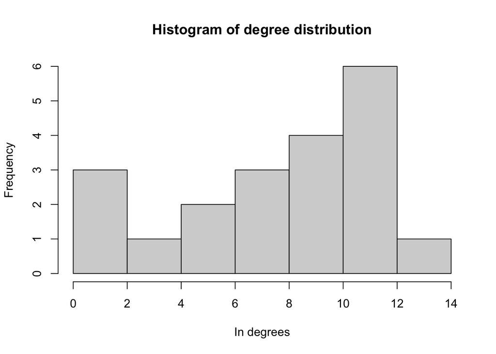

```r
hist (In_Degrees_FN, main = "Histogram of degree distribution", xlab = "In degrees") # Create the histogram
```

## **Problem # 4**

From the protein interaction network called “yeast”, write a program in R that:

**a.** Calculate the distribution of connectivities and plot that distribution.

First, load the data:

```r
library (igraph) # Load library
library (igraphdata) # Load library

data ("yeast") # Load data
```

Then, calculate the degrees and degree distribution:

```r
Yeast_Degree <- degree (yeast) # Check the degrees
head (Yeast_Degree) # Only look at the first ones
```

```
## YLR197W YOR039W YDR473C YOR332W YER090W YDR394W
##      40      19       9      13      21      37
```

```r
Yeast_D_D <- degree_distribution (yeast) # Check the degree distribution
Yeast_D_D # Print
```

```
##   [1] 0.0000000000 0.2651891479 0.1287734047 0.0924722965 0.0676346962
##   [6] 0.0550248376 0.0424149790 0.0366832251 0.0248376003 0.0229270157
##  [11] 0.0275124188 0.0171952618 0.0152846771 0.0210164310 0.0145204433
##  [16] 0.0133740925 0.0133740925 0.0064959878 0.0080244555 0.0057317539
##  [21] 0.0095529232 0.0106992740 0.0072602216 0.0053496370 0.0057317539
##  [26] 0.0026748185 0.0038211693 0.0026748185 0.0026748185 0.0007642339
##  [31] 0.0015284677 0.0042032862 0.0042032862 0.0007642339 0.0038211693
##  [36] 0.0034390524 0.0030569354 0.0015284677 0.0019105846 0.0019105846
##  [41] 0.0045854031 0.0015284677 0.0034390524 0.0026748185 0.0011463508
##  [46] 0.0007642339 0.0011463508 0.0003821169 0.0007642339 0.0003821169
##  [51] 0.0007642339 0.0007642339 0.0022927016 0.0022927016 0.0011463508
##  [56] 0.0019105846 0.0007642339 0.0015284677 0.0011463508 0.0000000000
##  [61] 0.0003821169 0.0000000000 0.0007642339 0.0000000000 0.0000000000
##  [66] 0.0000000000 0.0000000000 0.0000000000 0.0003821169 0.0000000000
##  [71] 0.0000000000 0.0000000000 0.0000000000 0.0003821169 0.0000000000
##  [76] 0.0000000000 0.0000000000 0.0000000000 0.0000000000 0.0000000000
##  [81] 0.0000000000 0.0000000000 0.0000000000 0.0000000000 0.0000000000
##  [86] 0.0000000000 0.0003821169 0.0000000000 0.0000000000 0.0000000000
##  [91] 0.0007642339 0.0003821169 0.0000000000 0.0003821169 0.0003821169
##  [96] 0.0003821169 0.0000000000 0.0003821169 0.0000000000 0.0000000000
## [101] 0.0000000000 0.0003821169 0.0003821169 0.0000000000 0.0038211693
## [106] 0.0000000000 0.0015284677 0.0003821169 0.0011463508 0.0000000000
## [111] 0.0000000000 0.0000000000 0.0000000000 0.0007642339 0.0003821169
## [116] 0.0003821169 0.0000000000 0.0000000000 0.0003821169
```

Finally, the plot:

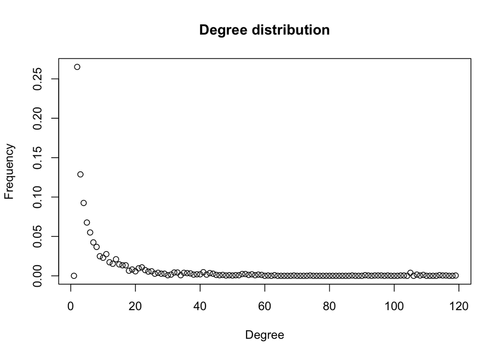

```
Discussion: It is definetely a long tail network, a lot of the nodes have a few connections, but a few nodes have a lot connections.
```

```r
plot (degree_distribution (yeast), main = "Degree distribution", xlab = "Degree", ylab = "Frequency") # Plot
```

**b.** Plot the boxplot of the connectivity distribution and discuss the result.

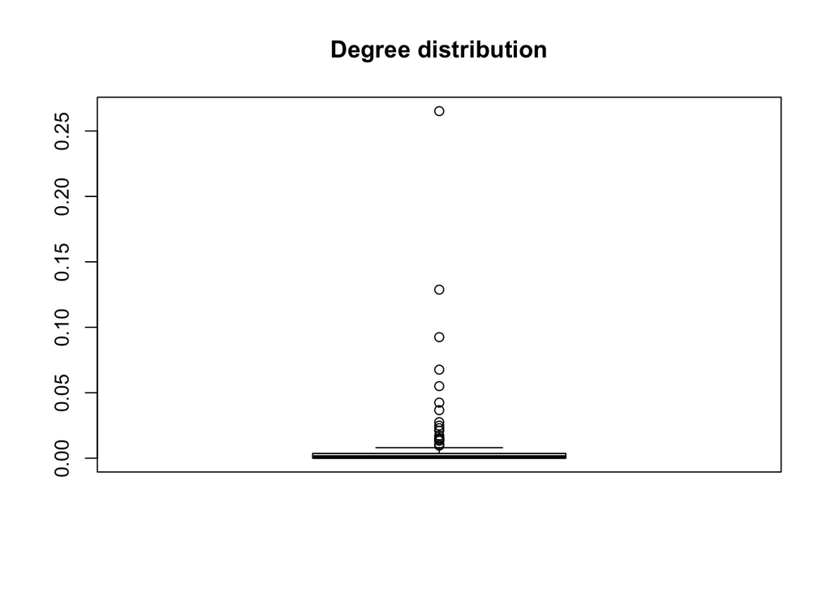

```
Discussion: It is long tail because almost all the nodes have a few connections (median inside de box) and just a few, a lot. The distribution is not normal.
```

```r
Boxplot_DD_Y <- boxplot (Yeast_D_D, main = "Degree distribution") # Make the boxplot
```

**c.** Find the proportion of nodes that have 15 or more connectivities.

First, find the length of all the data:

```r
Length_D <- length (Yeast_Degree) # Find the length of the complete data
Length_D # Print
```

```
## [1] 2617
```

Then, find which nodes have 15 or more connections and the total of those nodes:

```r
More_15 <- which (Yeast_Degree >= 15) # Find which nodes have 15 or more connections (the numbers are the position, not the connections)
More_15 # Print
```

[output not shown]

[output cut: 57 more lines]

```
##      1294      1308      1310      1314      1315      1329      1331      1337
##   YBR088C   YMR208W   YDR428C   YML007W   YPL042C   YGL025C   YDL142C   YDL209C
##      1340      1377      1380      1385      1409      1414      1423      1435
##   YBR041W   YJR057W   YJR070C   YPL227C   YNL168C   YDR441C   YDR292C   YML004C
##      1456      1484      1513      1531      1549      1551      1555      1556
##   YJR148W   YHR206W   YHR088W   YEL050C   YFL033C   YOL060C   YJR008W   YPR183W
##      1584      1587      1589      1608      1629      1631      1645      1673
##   YMR190C   YEL061C   YLR071C   YKL113C   YNL271C   YDR162C   YBR234C   YJL020C
##      1817      1848      1856      1878      1898      1908      1913      1930
##   YNL110C   YGR193C   YBR247C   YJR016C   YGR128C   YCL054W   YLR276C   YLR275W
##      1936      1953      1976      1982      1991      1995      1996      2026
##   YHL004W   YLR277C   YOR221C   YGL048C   YOR224C   YLR006C   YJR017C   YJR014W
##      2131      2159      2160      2173      2191      2213      2274      2327
##   YGR194C
##      2376
```

```r
Length_15 <- length (More_15) # Find the length of the nodes that have 15 or more connections
Length_15 # Print
```

```
## [1] 441
```

Finally, calculate the proportion:

```r
Proportion_15 <- (Length_15 * 100) / Length_D # Calculate the proportion
Proportion_15 # Print
```

```
## [1] 16.85136
```

**d.** Calculate the maximum degree of the network.

```r
Max_Degree <- max (Yeast_Degree) # Obtain the maximum degree
Max_Degree # Print
```

```
## [1] 118
```

**e.** Calculate the diameter.

```r
Diameter_Y <- diameter (yeast) # Calculate the diameter
Diameter_Y # Print
```

```
## [1] 15
```

**f.** The longest path.

```r
Longest_Path_Y <- get_diameter(yeast) # Obtain the longest path (15)
Longest_Path_Y # Print
```

```
## + 16/2617 vertices, named, from 65c41bb:
##  [1] YPL259C YPR029C YLR170C YGL206C YER177W YDR028C YGL115W YDR422C YHR114W
## [10] YBL007C YNL271C YLR190W YIL050W YPL031C YER059W YDL224C
```

```
The longest path is: YPL259C YPR029C YLR170C YGL206C YER177W YDR028C YGL115W YDR422C YHR114W YBL007C YNL271C YLR190W YIL050W YPL031C YER059W YDL224C, with 16 proteins, 15 steps
```

**g.** Remove the 10 most connected nodes of the network and determine the diameter each time you do so.

First, assign the main values:

```r
i = 0 # Assign the value of i
First_10 <- sort (Yeast_Degree, decreasing = TRUE) [1:10]  # Sort and select the first 10 nodes (the ones with more connections)
First_10 # Print
```

```
## YPR110C YPL131W YNL178W YIL021W YOL127W YJL063C YBR283C YLR378C YMR260C YBR251W
##     118     115     114     113     113     108     108     108     107     106
```

```r
Diameter_Yeast <- c () # Create a vector to save the diameters
```

Then, create a loop for:

```r
for (i in 1 : 10) { # For i in 1 to 10
  Diameter_Yeast [i] <- diameter (yeast) # Calculate the diameter for network
  yeast <- delete_vertices (yeast, sample (First_10 [i])) # Delete the node corresponding to i
}
```

Finally, obtain the diameters on the vector:

```r
print (Diameter_Yeast) # Print
```

```
##  [1] 15 15 15 16 17 16 21 19 19 16
```

Reload the data, for further problems

```r
data ("yeast") # Load data
```

**h.** Determine the ten most important nodes by at least 3 measures of centrality.

1. Degree centrality

```r
Y_Degree_centrality <- degree (yeast) # Calculate the degree of the network
sort (Y_Degree_centrality, decreasing = TRUE) [1:10] # Order the data
```

```
## YPR110C YPL131W YNL178W YIL021W YOL127W YJL063C YBR283C YLR378C YMR260C YBR251W
##     118     115     114     113     113     108     108     108     107     106
```

```
Discussion: Those are the 10 most important proteins. It is because those proteins are the ones with more connections.
```

2. Eigenvector centrality

```r
Y_Eigenvector_Centrality <- eigen_centrality (yeast) # Calculate the eigenvector centrality of the network
sort (Y_Eigenvector_Centrality $ vector, decreasing = TRUE) [1:10] # Order the data
```

```
##   YPL131W   YNL178W   YOL127W   YBR283C   YLR378C   YGL123W   YNL284C   YGL103W
## 1.0000000 0.9927230 0.9924877 0.9702257 0.9702257 0.9693538 0.9693538 0.9693538
##   YBR251W   YOL040C
## 0.9693538 0.9619524
```

```
Discussion: Those are the 10 most important proteins. It is because those proteins are the ones with more influence on the network
```

3. Closness centrality

```r
Y_Closness_centrality <- closeness (yeast) # Calculate the closness centrality of the network
sort (Y_Closness_centrality, decreasing = TRUE) [1:10] # Order the data
```

```
##      YNL189W      YIL147C      YLR175W      YNR016C      YGL059W      YIL042C
## 1.559809e-06 1.558310e-06 1.558067e-06 1.558021e-06 1.557972e-06 1.557972e-06
##      YDL029W      YDR394W      YHL004W      YKL104C
## 1.557865e-06 1.557630e-06 1.557562e-06 1.557543e-06
```

```
Discussion: Those are the 10 most important proteins. It is because those proteins are the closest to other nodes
```

**i.** Cluster the network by at least two methods and determine the size of the largest cluster.

1. Cluster by community structure detecting based on the leading eigenvector of the community matrix

First, create the clusters:

```r
Cluster_LE_Y <- cluster_leading_eigen (yeast) # Create the cluster
Cluster_LE_Y # Print
```

```
## IGRAPH clustering leading eigenvector, groups: 99, mod: 0.64
## + groups:
##   $`1`
##     [1] "YLR197W" "YOR039W" "YOR061W" "YGL049C" "YPL093W" "YER006W" "YHR052W"
##     [8] "YGR162W" "YOL041C" "YHR197W" "YLL008W" "YPL043W" "YOR310C" "YNL002C"
##    [15] "YKL014C" "YPL012W" "YMR049C" "YLR409C" "YLR222C" "YOL077C" "YPL126W"
##    [22] "YDL060W" "YFR001W" "YKR081C" "YDR496C" "YDR087C" "YGR145W" "YMR309C"
##    [29] "YIR001C" "YDR091C" "YGR103W" "YGL019W" "YPR016C" "YOR272W" "YNL132W"
##    [36] "YOR206W" "YNL061W" "YMR290C" "YBL004W" "YGR090W" "YGL111W" "YDR299W"
##    [43] "YJL109C" "YDL145C" "YDL031W" "YDR449C" "YER082C" "YKL172W" "YCR057C"
##    [50] "YDR324C" "YGR245C" "YKR060W" "YBL002W" "YNL207W" "YGL120C" "YLR129W"
##    [57] "YPL266W" "YDL014W" "YIL093C" "YKL143W" "YAL035W" "YOR056C" "YLR449W"
##   + ... omitted several groups/vertices
```

Then, obtain the information:

```r
membership (Cluster_LE_Y) # Obtain which member are in which clusters
```

[output not shown]

[output cut: 601 more lines]

```
##        96        86        96        96        18        96        96        41
##   YHR010W   YPR116W   YDR369C   YGL163C   YDR217C   YBR215W   YOL068C   YOR025W
##        96        96        96        96        96        96        96        96
##   YMR224C   YNL171C   YOR160W   YAL026C   YLR425W   YNL289W   YMR299C   YOR153W
##        96        96        96        96        96        96        96        95
##   YKR047W   YIL159W   YOR058C   YDR149C   YDL117W   YLR381W   YJR053W   YDR289C
##        96        96        96        96        96        96        96        96
##   YBR095C   YBR107C   YNL170W   YHR191C   YBR231C   YNL215W   YNL307C YML095C-A
##        96        96        96        96        96        96        96        96
##   YML016C   YCL016C   YJR143C   YOR321W   YKL092C   YLR372W   YOR027W   YER068W
##        96        96        32        32        96        87        97        88
##   YER122C   YKL020C   YDR351W   YLR433C   YKL190W   YLL050C   YLR235C   YNL098C
##        96        89        90        97        97        91        96        96
##   YMR060C
##        92
```

```r
table (membership (Cluster_LE_Y)) # Obtain the number of members by clusters
```

```
##
##    1    2    3    4    5    6    7    8    9   10   11   12   13   14   15   16
##  179    3    5    5    7    6    4    3    5    2    7    2    2    7    3    2
##   17   18   19   20   21   22   23   24   25   26   27   28   29   30   31   32
##    2    4    2    2    2    2    2    2    2    2    2    2    2    2    2    4
##   33   34   35   36   37   38   39   40   41   42   43   44   45   46   47   48
##    2    2    2    2    2    5    2    2    3    2    2    3    2    2    5    3
##   49   50   51   52   53   54   55   56   57   58   59   60   61   62   63   64
##    3    2    2    2    2    3    3    2    2    2    2    2    2    2    2    2
##   65   66   67   68   69   70   71   72   73   74   75   76   77   78   79   80
##    2    2    2    2    2    2    2    3    5    3    3    4    2    2    2    2
##   81   82   83   84   85   86   87   88   89   90   91   92   93   94   95   96
##    2    3    2    2    4    2    2    2    2    2    2    2  175  159   78 1483
##   97   98   99
##  177  105   19
```

```r
sort (table (membership (Cluster_LE_Y)), decreasing = TRUE) # Sort the members of the cluster
```

```
##
##   96    1   97   93   94   98   95   99    5   11   14    6    3    4    9   38
## 1483  179  177  175  159  105   78   19    7    7    7    6    5    5    5    5
##   47   73    7   18   32   76   85    2    8   15   41   44   48   49   54   55
##    5    5    4    4    4    4    4    3    3    3    3    3    3    3    3    3
##   72   74   75   82   10   12   13   16   17   19   20   21   22   23   24   25
##    3    3    3    3    2    2    2    2    2    2    2    2    2    2    2    2
##   26   27   28   29   30   31   33   34   35   36   37   39   40   42   43   45
##    2    2    2    2    2    2    2    2    2    2    2    2    2    2    2    2
##   46   50   51   52   53   56   57   58   59   60   61   62   63   64   65   66
##    2    2    2    2    2    2    2    2    2    2    2    2    2    2    2    2
##   67   68   69   70   71   77   78   79   80   81   83   84   86   87   88   89
##    2    2    2    2    2    2    2    2    2    2    2    2    2    2    2    2
##   90   91   92
##    2    2    2
```

```
The larger cluster is cluster number 96, which has 1,483 proteins
```

2. Cluster via greedy optimization of modularity

First, create the clusters:

```r
Cluster_FG_Y <- cluster_fast_greedy (yeast) # Create the cluster
Cluster_FG_Y# Print
```

```
## IGRAPH clustering fast greedy, groups: 127, mod: 0.7
## + groups:
##   $`1`
##     [1] "YER090W"   "YDR394W"   "YER021W"   "YGL026C"   "YPR010C"   "YFR052W"
##     [7] "YOR261C"   "YBL045C"   "YGL220W"   "YOR117W"   "YDR127W"   "YMR205C"
##    [13] "YER081W"   "YER094C"   "YGR264C"   "YDR354W"   "YER178W"   "YNL071W"
##    [19] "YBR221C"   "YDR190C"   "YNR016C"   "YKL182W"   "YIL125W"   "YDL097C"
##    [25] "YKL145W"   "YFL018C"   "YCL030C"   "YBR256C"   "YPR051W"   "YMR189W"
##    [31] "YFR004W"   "YDL007W"   "YHR200W"   "YAL044C"   "YOL058W"   "YBL033C"
##    [37] "YDR158W"   "YOR259C"   "YIL116W"   "YHL030W"   "YKL067W"   "YCL017C"
##    [43] "YGL137W"   "YPR108W"   "YER069W"   "YJL138C"   "YPL135W"   "YOL038W"
##    [49] "YOL021C"   "YDL147W"   "YMR314W"   "YGR135W"   "YJL088W"   "YPL111W"
##   + ... omitted several groups/vertices
```

Then, obtain the information:

```r
membership (Cluster_FG_Y) # Obtain which member are in which clusters
```

[output not shown]

[output cut: 601 more lines]

```
##         6        78         4         4        46         7         4        60
##   YHR010W   YPR116W   YDR369C   YGL163C   YDR217C   YBR215W   YOL068C   YOR025W
##         6         6         6         6         6         6         6         6
##   YMR224C   YNL171C   YOR160W   YAL026C   YLR425W   YNL289W   YMR299C   YOR153W
##         6         6         4         7         7         7         7         5
##   YKR047W   YIL159W   YOR058C   YDR149C   YDL117W   YLR381W   YJR053W   YDR289C
##         7         7         7         7         7         7         7         7
##   YBR095C   YBR107C   YNL170W   YHR191C   YBR231C   YNL215W   YNL307C YML095C-A
##         7         7         7         7         7         7         7         7
##   YML016C   YCL016C   YJR143C   YOR321W   YKL092C   YLR372W   YOR027W   YER068W
##         7         7        48        48         7        76         1        75
##   YER122C   YKL020C   YDR351W   YLR433C   YKL190W   YLL050C   YLR235C   YNL098C
##         7        74        73         7         7        72         7         7
##   YMR060C
##        71
```

```r
table (membership (Cluster_FG_Y)) # Obtain the number of members by clusters
```

```
##
##   1   2   3   4   5   6   7   8   9  10  11  12  13  14  15  16  17  18  19  20
## 744 372 182  86  82 186 364  55  27  29  22  34  24  15  15  11  15  13   7   7
##  21  22  23  24  25  26  27  28  29  30  31  32  33  34  35  36  37  38  39  40
##  10   8   9   6   6   4   5   5   5   5   5   7   6   8   7   5   4   4   7   3
##  41  42  43  44  45  46  47  48  49  50  51  52  53  54  55  56  57  58  59  60
##   5   4   5   4   4   4   4   4   3   3   3   3   3   3   3   3   3   3   3   3
##  61  62  63  64  65  66  67  68  69  70  71  72  73  74  75  76  77  78  79  80
##   3   3   3   3   2   2   2   2   2   2   2   2   2   2   2   2   2   2   2   2
##  81  82  83  84  85  86  87  88  89  90  91  92  93  94  95  96  97  98  99 100
##   2   2   2   2   2   2   2   2   2   2   2   2   2   2   2   2   2   2   2   2
## 101 102 103 104 105 106 107 108 109 110 111 112 113 114 115 116 117 118 119 120
##   2   2   2   2   2   2   2   2   2   2   2   2   2   2   2   2   2   2   2   2
## 121 122 123 124 125 126 127
##   2   2   2   2   2   2   2
```

```r
sort (table (membership (Cluster_FG_Y)), decreasing = TRUE) # Sort the members of the cluster
```

```
##
##   1   2   7   6   3   4   5   8  12  10   9  13  11  14  15  17  18  16  21  23
## 744 372 364 186 182  86  82  55  34  29  27  24  22  15  15  15  13  11  10   9
##  22  34  19  20  32  35  39  24  25  33  27  28  29  30  31  36  41  43  26  37
##   8   8   7   7   7   7   7   6   6   6   5   5   5   5   5   5   5   5   4   4
##  38  42  44  45  46  47  48  40  49  50  51  52  53  54  55  56  57  58  59  60
##   4   4   4   4   4   4   4   3   3   3   3   3   3   3   3   3   3   3   3   3
##  61  62  63  64  65  66  67  68  69  70  71  72  73  74  75  76  77  78  79  80
##   3   3   3   3   2   2   2   2   2   2   2   2   2   2   2   2   2   2   2   2
##  81  82  83  84  85  86  87  88  89  90  91  92  93  94  95  96  97  98  99 100
##   2   2   2   2   2   2   2   2   2   2   2   2   2   2   2   2   2   2   2   2
## 101 102 103 104 105 106 107 108 109 110 111 112 113 114 115 116 117 118 119 120
##   2   2   2   2   2   2   2   2   2   2   2   2   2   2   2   2   2   2   2   2
## 121 122 123 124 125 126 127
##   2   2   2   2   2   2   2
```

```
The larger cluster is cluster number 1, which has 744 proteins
```

Finally, compare the clusters:

```r
Comparation <- compare (Cluster_LE_Y, Cluster_FG_Y, method = "adjusted.rand") # Compare clusters
Comparation # Print
```

```
## [1] 0.1601622
```

```
0.1601622 = not similar
```

**j.** Determine if the network is small world, ultra small world, or other.

Create an histogram to see the distribution of the nodes and their conections

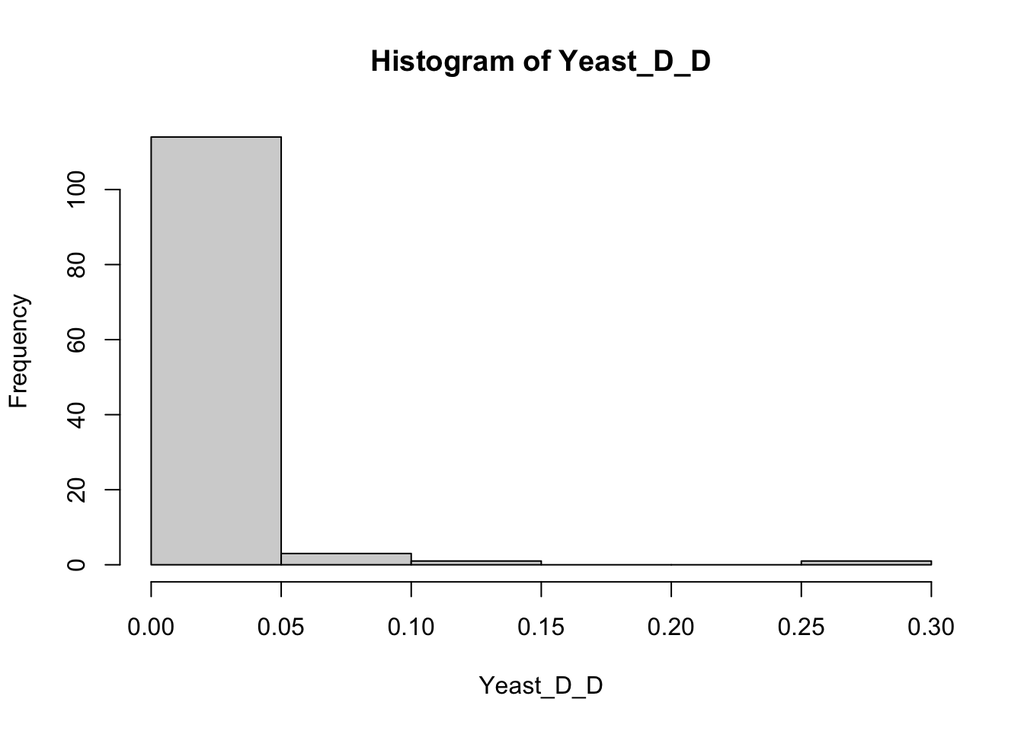

[output not shown]

```r
hist (Yeast_D_D) # Create histogram
```